# 월마트 대회 with Tidymodels

Elestic net 튜닝에 대하여 알아보자.

[figure not shown]

Photo steal from [here](https://connectedremag.com/das-in-building-wireless/walmart-verizon-explore-testing-5g-in-some-stores/)

본 포스팅은 [슬기로운 통계생활 캐글 R 스터디](https://www.youtube.com/playlist?list=PLKtLBdGREmMlJCXjCpCi5B4KQ-TsFvAAi) 발표용 포스팅입니다.

# 1 준비작업

## 1.1 Library load

이번 포스팅에서 사용할 R패키지들을 불러오자. 특히 요즘 핫하디 핫한 `tidymodels` 사용하여 월마트 대회를 가지고 놀아본다. 또한 마이 빼이보릿 연산자들을 사용하기 위하여 `magrittr`를 불러왔다.🤣

```r
library(tidymodels)
library(tidyverse)
library(magrittr)
library(skimr)
library(knitr)
theme_set(theme_bw())
```

## 1.2 Dataset load

이 대회에서 주어진 데이터셋을 불러보자. 주어진 파일 리스트는 다음과 같다.

```r
file_path <- "../input/walmart-recruiting-store-sales-forecasting/"
files <- list.files(file_path)
files
```

```
## [1] "features.csv.zip"         "sampleSubmission.csv.zip"
## [3] "stores.csv"               "test.csv.zip"
## [5] "train.csv.zip"
```

각 변수의 이름을 `janitor` 패키지로 말끔하게 바꿔준다.

```r
train <- read_csv(file.path(file_path, "train.csv.zip")) %>%
  janitor::clean_names()
test <- read_csv(file.path(file_path, "test.csv.zip")) %>%
  janitor::clean_names()
features <- read_csv(file.path(file_path, "features.csv.zip")) %>%
  janitor::clean_names()
stores <- read_csv(file.path(file_path, "stores.csv")) %>%
  janitor::clean_names()
```

# 2 데이터 기본정보 확인

## 2.1 Basic info.

이 대회는 기본적으로 간단한 대회이다. 첫번째 스터디용 대회로 선택을 한 이유이기도 하다. 주 데이터는 42만개의 train 샘플과 11만개의 test 샘플로 구성이 되어있다.

```r
dim(train)
```

```
## [1] 421570      5
```

```r
dim(test)
```

```
## [1] 115064      4
```

변수명을 살펴보면, 월마트 가맹점을 뜻하는 `store` 변수와 매장안의 부서들을 나타내는 `dept`, 날짜 정보를 가지고 있는 `date`와 `is_holiday`, 마지막으로 우리의 target 변수인 `weekly_sales`가 있는 것을 확인 할 수 있다.

```r
names(train)
```

```
## [1] "store"        "dept"         "date"         "weekly_sales" "is_holiday"
```

```r
names(test)
```

```
## [1] "store"      "dept"       "date"       "is_holiday"
```

## 2.2 train data

```r
skim(train)
```

Data summary

| Name | train |
| --- | --- |
| Number of rows | 421570 |
| Number of columns | 5 |
| _______________________ |  |
| Column type frequency: |  |
| Date | 1 |
| logical | 1 |
| numeric | 3 |
| ________________________ |  |
| Group variables | None |

**Variable type: Date**

| skim_variable | n_missing | complete_rate | min | max | median | n_unique |
| --- | --- | --- | --- | --- | --- | --- |
| date | 0 | 1 | 2010-02-05 | 2012-10-26 | 2011-06-17 | 143 |

**Variable type: logical**

| skim_variable | n_missing | complete_rate | mean | count |
| --- | --- | --- | --- | --- |
| is_holiday | 0 | 1 | 0.07 | FAL: 391909, TRU: 29661 |

**Variable type: numeric**

| skim_variable | n_missing | complete_rate | mean | sd | p0 | p25 | p50 | p75 | p100 | hist |
| --- | --- | --- | --- | --- | --- | --- | --- | --- | --- | --- |
| store | 0 | 1 | 22.20 | 12.79 | 1.00 | 11.00 | 22.00 | 33.00 | 45.0 | ▇▇▇▇▇ |
| dept | 0 | 1 | 44.26 | 30.49 | 1.00 | 18.00 | 37.00 | 74.00 | 99.0 | ▇▇▅▂▆ |
| weekly_sales | 0 | 1 | 15981.26 | 22711.18 | -4988.94 | 2079.65 | 7612.03 | 20205.85 | 693099.4 | ▇▁▁▁▁ |

## 2.3 test data

```r
skim(test)
```

Data summary

| Name | test |
| --- | --- |
| Number of rows | 115064 |
| Number of columns | 4 |
| _______________________ |  |
| Column type frequency: |  |
| Date | 1 |
| logical | 1 |
| numeric | 2 |
| ________________________ |  |
| Group variables | None |

**Variable type: Date**

| skim_variable | n_missing | complete_rate | min | max | median | n_unique |
| --- | --- | --- | --- | --- | --- | --- |
| date | 0 | 1 | 2012-11-02 | 2013-07-26 | 2013-03-15 | 39 |

**Variable type: logical**

| skim_variable | n_missing | complete_rate | mean | count |
| --- | --- | --- | --- | --- |
| is_holiday | 0 | 1 | 0.08 | FAL: 106136, TRU: 8928 |

**Variable type: numeric**

| skim_variable | n_missing | complete_rate | mean | sd | p0 | p25 | p50 | p75 | p100 | hist |
| --- | --- | --- | --- | --- | --- | --- | --- | --- | --- | --- |
| store | 0 | 1 | 22.24 | 12.81 | 1 | 11 | 22 | 33 | 45 | ▇▇▇▇▇ |
| dept | 0 | 1 | 44.34 | 30.66 | 1 | 18 | 37 | 74 | 99 | ▇▇▅▂▆ |

## 2.4 store data

`store` 데이터는 상대적으로 간단하다. 각 점포에 대한 사이즈와 타입변수가 담겨져 있다. 타입변수는 월마트에서 운영하는 supercenter와 같이 매장의 성격을 나타내는 변수이다.

```r
dim(stores)
```

```
## [1] 45  3
```

```r
head(stores)
```

```
## # A tibble: 6 x 3
##   store type    size
##   <dbl> <chr>  <dbl>
## 1     1 A     151315
## 2     2 A     202307
## 3     3 B      37392
## 4     4 A     205863
## 5     5 B      34875
## 6     6 A     202505
```

```r
skim(stores)
```

Data summary

| Name | stores |
| --- | --- |
| Number of rows | 45 |
| Number of columns | 3 |
| _______________________ |  |
| Column type frequency: |  |
| character | 1 |
| numeric | 2 |
| ________________________ |  |
| Group variables | None |

**Variable type: character**

| skim_variable | n_missing | complete_rate | min | max | empty | n_unique | whitespace |
| --- | --- | --- | --- | --- | --- | --- | --- |
| type | 0 | 1 | 1 | 1 | 0 | 3 | 0 |

**Variable type: numeric**

| skim_variable | n_missing | complete_rate | mean | sd | p0 | p25 | p50 | p75 | p100 | hist |
| --- | --- | --- | --- | --- | --- | --- | --- | --- | --- | --- |
| store | 0 | 1 | 23.0 | 13.13 | 1 | 12 | 23 | 34 | 45 | ▇▇▇▇▇ |
| size | 0 | 1 | 130287.6 | 63825.27 | 34875 | 70713 | 126512 | 202307 | 219622 | ▆▂▅▂▇ |

## 2.5 feature data

`feature` 데이터는 조금 복잡한데, 각 점포별로 각 주마다의 정보가 담겨있는 것을 알 수 있다.

```r
dim(features)
```

```
## [1] 8190   12
```

```r
length(unique(features$Store)) * length(unique(features$Date))
```

```
## [1] 0
```

```r
head(features)
```

```
## # A tibble: 6 x 12
##   store date       temperature fuel_price mark_down1 mark_down2 mark_down3
##   <dbl> <date>           <dbl>      <dbl>      <dbl>      <dbl>      <dbl>
## 1     1 2010-02-05        42.3       2.57         NA         NA         NA
## 2     1 2010-02-12        38.5       2.55         NA         NA         NA
## 3     1 2010-02-19        39.9       2.51         NA         NA         NA
## 4     1 2010-02-26        46.6       2.56         NA         NA         NA
## 5     1 2010-03-05        46.5       2.62         NA         NA         NA
## 6     1 2010-03-12        57.8       2.67         NA         NA         NA
## # ... with 5 more variables: mark_down4 <dbl>, mark_down5 <dbl>, cpi <dbl>,
## #   unemployment <dbl>, is_holiday <lgl>
```

일단 `NA`의 존재가 많음. `skim()` 함수의 complete 정보를 통하여 알아 볼 수 있다. 또한, 대회 데이터에 대한 설명을 보면 `mark_down1-5` 변수의 경우 월마트에서 진행하고 있는 Promotion을 의미한다. 하지만 이 변수의 경우 2011년 11월 이후에 날짜에 대하여만 접근 가능하고, 그 이전의 경우에는 `NA`로 채워져있다. 이러한 `NA`를 어떻게 사용할 것인가가 이 대회의 핵심일 것 같다.

```r
skim(features)
```

Data summary

| Name | features |
| --- | --- |
| Number of rows | 8190 |
| Number of columns | 12 |
| _______________________ |  |
| Column type frequency: |  |
| Date | 1 |
| logical | 1 |
| numeric | 10 |
| ________________________ |  |
| Group variables | None |

**Variable type: Date**

| skim_variable | n_missing | complete_rate | min | max | median | n_unique |
| --- | --- | --- | --- | --- | --- | --- |
| date | 0 | 1 | 2010-02-05 | 2013-07-26 | 2011-10-31 | 182 |

**Variable type: logical**

| skim_variable | n_missing | complete_rate | mean | count |
| --- | --- | --- | --- | --- |
| is_holiday | 0 | 1 | 0.07 | FAL: 7605, TRU: 585 |

**Variable type: numeric**

| skim_variable | n_missing | complete_rate | mean | sd | p0 | p25 | p50 | p75 | p100 | hist |
| --- | --- | --- | --- | --- | --- | --- | --- | --- | --- | --- |
| store | 0 | 1.00 | 23.00 | 12.99 | 1.00 | 12.00 | 23.00 | 34.00 | 45.00 | ▇▇▇▇▇ |
| temperature | 0 | 1.00 | 59.36 | 18.68 | -7.29 | 45.90 | 60.71 | 73.88 | 101.95 | ▁▂▆▇▃ |
| fuel_price | 0 | 1.00 | 3.41 | 0.43 | 2.47 | 3.04 | 3.51 | 3.74 | 4.47 | ▅▅▇▇▁ |
| mark_down1 | 4158 | 0.49 | 7032.37 | 9262.75 | -2781.45 | 1577.53 | 4743.58 | 8923.31 | 103184.98 | ▇▁▁▁▁ |
| mark_down2 | 5269 | 0.36 | 3384.18 | 8793.58 | -265.76 | 68.88 | 364.57 | 2153.35 | 104519.54 | ▇▁▁▁▁ |
| mark_down3 | 4577 | 0.44 | 1760.10 | 11276.46 | -179.26 | 6.60 | 36.26 | 163.15 | 149483.31 | ▇▁▁▁▁ |
| mark_down4 | 4726 | 0.42 | 3292.94 | 6792.33 | 0.22 | 304.69 | 1176.42 | 3310.01 | 67474.85 | ▇▁▁▁▁ |
| mark_down5 | 4140 | 0.49 | 4132.22 | 13086.69 | -185.17 | 1440.83 | 2727.14 | 4832.56 | 771448.10 | ▇▁▁▁▁ |
| cpi | 585 | 0.93 | 172.46 | 39.74 | 126.06 | 132.36 | 182.76 | 213.93 | 228.98 | ▇▁▁▂▆ |
| unemployment | 585 | 0.93 | 7.83 | 1.88 | 3.68 | 6.63 | 7.81 | 8.57 | 14.31 | ▂▇▇▁▁ |

# 3 탐색적 데이터 분석 및 시각화

## 3.1 `weekly_sales`

먼저 우리의 예측 목표인 주간 세일변수 `weekly_sales`를 시각화 해보도록 하자.

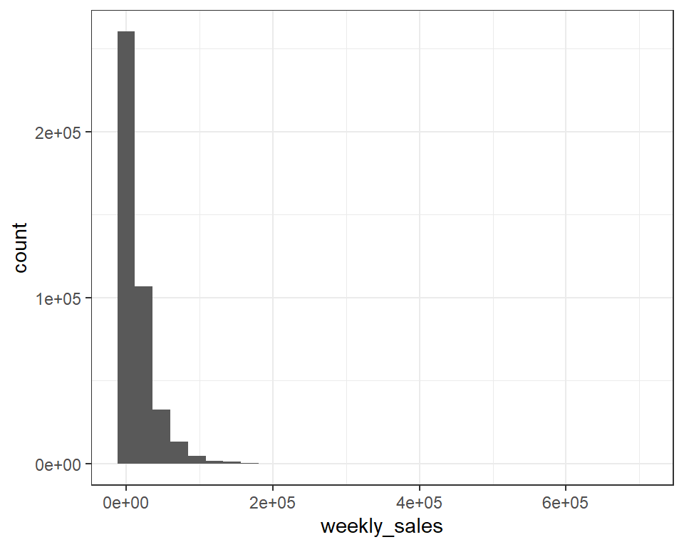

```r
train %>%
  ggplot(aes(x = weekly_sales)) +
  geom_histogram()
```

매출액의 분포라서 오른쪽으로 엄청 치우쳐있는 것을 알 수 있다. 이런 경우 보통 `log` 함수를 취해줘서 분포의 치우침을 잡아준다. 이렇게 분포 치우침을 잡아주는 이유는 회귀분석 같은 전통적인 기법의 경우 데이터에 섞여있는 잡음의 분포를 정규분포같이 대칭인 분포로 가정하는 경우가 많기 때문이다.

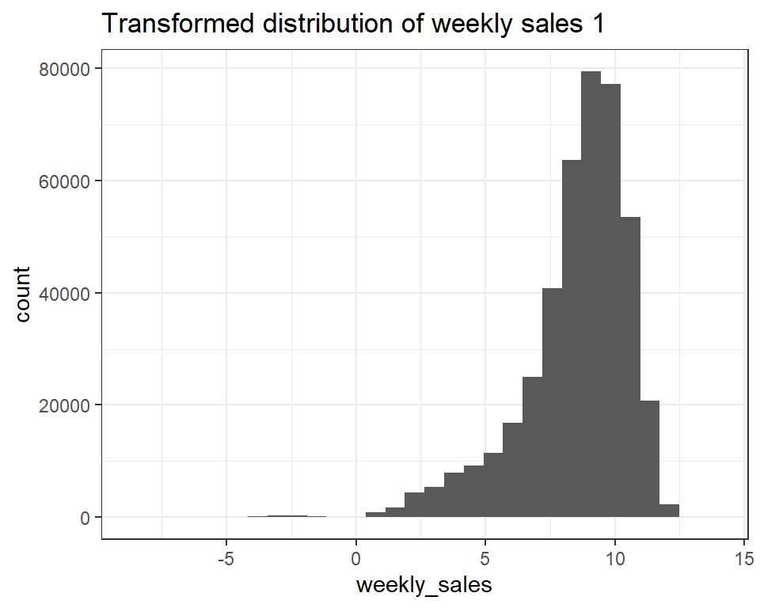

```r
train %>%
    ggplot(aes(x = sign(weekly_sales) * log(abs(weekly_sales) + 2))) +
    geom_histogram() +
    labs(title = "Transformed distribution of weekly sales 1",
         x = "weekly_sales")
```

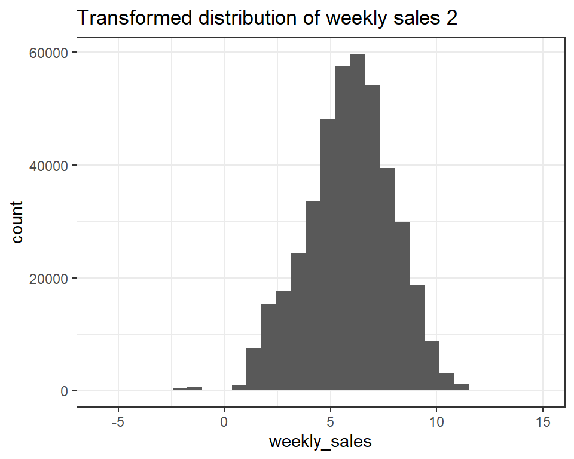

```r
train %>%
    ggplot(aes(x = sign(weekly_sales) * (abs(weekly_sales))^(1/5))) +
    geom_histogram() +
    labs(title = "Transformed distribution of weekly sales 2",
         x = "weekly_sales")
```

## 3.2 NA analysis

R에는 결측치 분석을 아주 용이하게 해주는 패키지가 하나 존재하는데, 바로 `naniar`라는 패키지 이다.

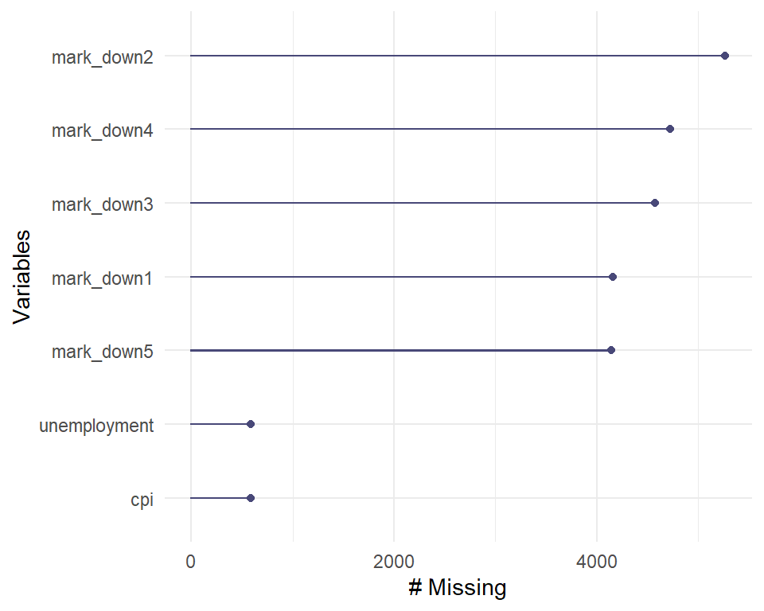

```r
library(naniar)
features %>%
  select_if(~sum(is.na(.)) > 0) %>% # 결측치 있는 칼럼 선택
  gg_miss_var()
```

`gg_miss_var()`를 통하여 현재 mark_down1-5 변수, 그리고, unemploment와 cpi가 결측치가 존재하는 것을 확인하였다.

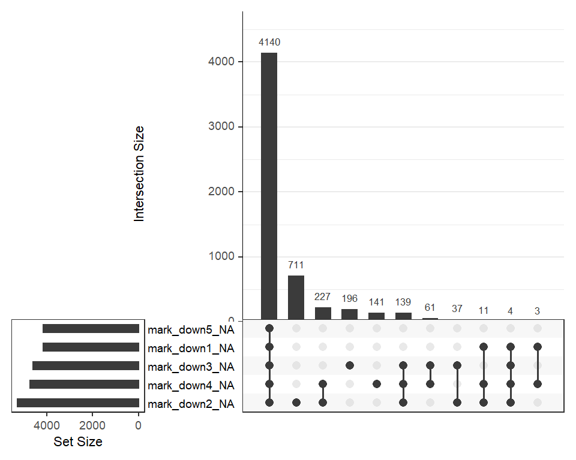

```r
features %>%
  select_if(~sum(is.na(.)) > 0) %>%
  gg_miss_upset()
```

`gg_miss_upset()` 함수의 경우 결측치가 동시에 발생하는 변수들을 보여주는데, mark_down1-5까지가 동시에 없는 결측치의 경우 (첫번째 기둥) 2011년 11월 이전의 자료를 나타내는 것을 알 수 있다.

# 4 전처리 레시피(`recipe`) 만들기

tidymodels의 전처리 패키지지 recipe을 사용하여 전처리를 하도록하자.

## 4.1 `all_data` 합치기

```r
# train weekly_sales 변경
train %<>%
  mutate(weekly_sales = sign(weekly_sales) * (abs(weekly_sales))^(1/5))
  # mutate(weekly_sales = sign(weekly_sales) * log(abs(weekly_sales) + 2))

all_data <- bind_rows(train, test)
all_data <- left_join(all_data, stores, by = c("store"= "store"))
all_data <- features %>%
    select(-c(starts_with("mark"), is_holiday)) %>%
    left_join(all_data, y = ., by = c("store"= "store",
                                      "date" = "date"))

names(all_data)
```

```
##  [1] "store"        "dept"         "date"         "weekly_sales" "is_holiday"
##  [6] "type"         "size"         "temperature"  "fuel_price"   "cpi"
## [11] "unemployment"
```

```r
dim(all_data)
```

```
## [1] 536634     11
```

## 4.2 `NA` cpi와 unemployment 변수

`unemployment`과 `cpi`의 `NA` 값들의 경우, 결측치 값이 2013년 5, 6, 7월에 집중 되어 있는 것을 확인 할 수 있다.

```r
all_data %>%
    mutate(year = lubridate::year(date)) %>%
    mutate(month = lubridate::month(date)) %>%
    group_by(year, month) %>%
    summarise(count_na_cpi = sum(is.na(cpi)),
              count_na_unemp = sum(is.na(unemployment))) %>%
    filter(count_na_cpi > 0 | count_na_unemp > 0)
```

```
## # A tibble: 3 x 4
## # Groups:   year [1]
##    year month count_na_cpi count_na_unemp
##   <dbl> <dbl>        <int>          <int>
## 1  2013     5        14726          14726
## 2  2013     6        11704          11704
## 3  2013     7        11732          11732
```

## 4.3 `cpi`와 `unemployment` 변수 `NA` 결측치 채우기

`cpi`와 `unemployment`를 종속변수로 설정 후 년도, 월, 점포, 부서 변수를 이용해서 회귀분석을 이용하여 채우도록 한다.

```r
impute_var <- function(var, all_data, var_name){
  var_train <- all_data %>%
    select({{var}}, date, store, dept) %>%
    filter(!is.na({{var}}))
  var_test <- all_data %>%
    select({{var}}, date, store, dept) %>%
    filter(is.na({{var}}))

  var_rec <- recipe(as.formula(paste0(var_name, "~ .")), var_train) %>%
      step_mutate(store = as_factor(store),
                  dept = as_factor(dept),
                  year = lubridate::year(date),
                  month = lubridate::month(date)) %>%
      step_dummy(store, dept) %>%
      prep(training = var_train)
  var_train2 <- juice(var_rec)
  var_test2 <- bake(var_rec, var_test)

  lm_model <-
      linear_reg() %>%
      set_engine("lm")

  lm_fit <-
      lm_model %>%
      fit(as.formula(paste0(var_name, "~ .")), data = var_train2)

  var_impute <- predict(lm_fit, var_test2)
  var_impute$.pred
}
result_cpi <- impute_var(cpi, all_data, "cpi")
result_ump <- impute_var(unemployment, all_data, "unemployment")
all_data$cpi[is.na(all_data$cpi)] <- result_cpi
all_data$unemployment[is.na(all_data$unemployment)] <- result_ump
all_data %>% tail %>% kable()
```

| store | dept | date | weekly_sales | is_holiday | type | size | temperature | fuel_price | cpi | unemployment |
| --- | --- | --- | --- | --- | --- | --- | --- | --- | --- | --- |
| 45 | 98 | 2013-06-21 | NA | FALSE | B | 118221 | 70.13 | 3.626 | 193.8677 | 7.571855 |
| 45 | 98 | 2013-06-28 | NA | FALSE | B | 118221 | 76.05 | 3.639 | 193.9282 | 7.568233 |
| 45 | 98 | 2013-07-05 | NA | FALSE | B | 118221 | 77.50 | 3.614 | 193.9868 | 7.540216 |
| 45 | 98 | 2013-07-12 | NA | FALSE | B | 118221 | 79.37 | 3.614 | 194.0472 | 7.536595 |
| 45 | 98 | 2013-07-19 | NA | FALSE | B | 118221 | 82.84 | 3.737 | 194.1076 | 7.532974 |
| 45 | 98 | 2013-07-26 | NA | FALSE | B | 118221 | 76.06 | 3.804 | 194.1681 | 7.529352 |

```r
all_data %>%
    summarise_all(~sum(is.na(.)))
```

```
## # A tibble: 1 x 11
##   store  dept  date weekly_sales is_holiday  type  size temperature fuel_price
##   <int> <int> <int>        <int>      <int> <int> <int>       <int>      <int>
## 1     0     0     0       115064          0     0     0           0          0
## # ... with 2 more variables: cpi <int>, unemployment <int>
```

## 4.4 `NA` 와 markdown 1-5 변수

```r
mean_markdown <- features %>%
    filter(date >= "2012-01-01" & date < "2013-01-01") %>%
    mutate(month = lubridate::month(date)) %>%
    group_by(store, month) %>%
    summarise(across(mark_down1:mark_down5, mean, na.rm = T))

mean_markdown %>%
    summarise_all(~sum(is.na(.))) %>%
    colSums()
```

```
##      store      month mark_down1 mark_down2 mark_down3 mark_down4 mark_down5
##       1035          0          0         70         11         41          0
```

```r
markdown_features <- features %>%
    mutate(month = lubridate::month(date)) %>%
    left_join(y = mean_markdown, by = c("store"= "store",
                                              "month" = "month")) %>%
    mutate(mark_down1 = if_else(is.na(mark_down1.x), mark_down1.y, mark_down1.x),
           mark_down2 = if_else(is.na(mark_down1.x), mark_down2.y, mark_down2.x),
           mark_down3 = if_else(is.na(mark_down1.x), mark_down3.y, mark_down3.x),
           mark_down4 = if_else(is.na(mark_down1.x), mark_down4.y, mark_down4.x),
           mark_down5 = if_else(is.na(mark_down1.x), mark_down5.y, mark_down5.x)) %>%
    select(store, date, mark_down1:mark_down5)

all_data <- markdown_features %>%
    left_join(all_data, y = ., by = c("store"= "store",
                                      "date" = "date"))

options(max.print = 20)
names(all_data)
```

```
##  [1] "store"        "dept"         "date"         "weekly_sales" "is_holiday"
##  [6] "type"         "size"         "temperature"  "fuel_price"   "cpi"
## [11] "unemployment" "mark_down1"   "mark_down2"   "mark_down3"   "mark_down4"
## [16] "mark_down5"
```

## 4.5 공휴일 데이터 코딩

미국의 휴일 정보를 가지고있는 `step_holiday` 함수를 이용해서 미국 공휴일을 모두 빼오도록 한다. 다음은 미국 공휴일 목록이다.

```r
timeDate::listHolidays("US")
```

```
##  [1] "USChristmasDay"          "USColumbusDay"
##  [3] "USCPulaskisBirthday"     "USDecorationMemorialDay"
##  [5] "USElectionDay"           "USGoodFriday"
##  [7] "USInaugurationDay"       "USIndependenceDay"
##  [9] "USLaborDay"              "USLincolnsBirthday"
## [11] "USMemorialDay"           "USMLKingsBirthday"
## [13] "USNewYearsDay"           "USPresidentsDay"
## [15] "USThanksgivingDay"       "USVeteransDay"
## [17] "USWashingtonsBirthday"
```

```r
library(lubridate)

datedb <- data.frame(date = ymd("2010-1-1") + days(0:(365*4))) %>%
    filter(date > "2010-01-29" & date < "2013-07-27") %>%
    mutate(index = 0:(length(date)-1))
datedb$date %>% range()
```

```
## [1] "2010-01-30" "2013-07-26"
```

```r
all_data$date %>% range()
```

```
## [1] "2010-02-05" "2013-07-26"
```

```r
holiday_rec <- recipe(~ date + index, datedb) %>%
    step_holiday(date,
                 holidays = timeDate::listHolidays("US")) %>%
    step_mutate(index_mod = index %/% 7) %>%
    prep(training = datedb) %>%
    juice()

holiday_rec %<>%
    select(-date) %>%
    select(starts_with("date"), index_mod) %>%
    group_by(index_mod) %>%
    summarise_all(sum) %>%
    mutate(date = all_data$date %>% unique()) %>%
    select(date, dplyr::everything())

all_data <- holiday_rec %>%
    select(-index_mod) %>%
    left_join(all_data, y = ., by = c("date" = "date"))
all_data %>% head() %>%
  kable()
```

| store | dept | date | weekly_sales | is_holiday | type | size | temperature | fuel_price | cpi | unemployment | mark_down1 | mark_down2 | mark_down3 | mark_down4 | mark_down5 | date_USChristmasDay | date_USColumbusDay | date_USCPulaskisBirthday | date_USDecorationMemorialDay | date_USElectionDay | date_USGoodFriday | date_USInaugurationDay | date_USIndependenceDay | date_USLaborDay | date_USLincolnsBirthday | date_USMemorialDay | date_USMLKingsBirthday | date_USNewYearsDay | date_USPresidentsDay | … |
| --- | --- | --- | --- | --- | --- | --- | --- | --- | --- | --- | --- | --- | --- | --- | --- | --- | --- | --- | --- | --- | --- | --- | --- | --- | --- | --- | --- | --- | --- | --- |
| 1 | 1 | 2010-02-05 | 7.574000 | FALSE | A | 151315 | 42.31 | 2.572 | 211.0964 | 8.106 | 16931.265 | 7281.180 | 68.7925 | 12626.25 | 6015.672 | 0 | 0 | 0 | 0 | 0 | 0 | 0 | 0 | 0 | 0 | 0 | 0 | 0 | 0 | … |
| 1 | 1 | 2010-02-12 | 8.563003 | TRUE | A | 151315 | 38.51 | 2.548 | 211.2422 | 8.106 | 16931.265 | 7281.180 | 68.7925 | 12626.25 | 6015.672 | 0 | 0 | 0 | 0 | 0 | 0 | 0 | 0 | 0 | 1 | 0 | 0 | 0 | 0 | … |
| 1 | 1 | 2010-02-19 | 8.390916 | FALSE | A | 151315 | 39.93 | 2.514 | 211.2891 | 8.106 | 16931.265 | 7281.180 | 68.7925 | 12626.25 | 6015.672 | 0 | 0 | 0 | 0 | 0 | 0 | 0 | 0 | 0 | 0 | 0 | 0 | 0 | 1 | … |
| 1 | 1 | 2010-02-26 | 7.204041 | FALSE | A | 151315 | 46.63 | 2.561 | 211.3196 | 8.106 | 16931.265 | 7281.180 | 68.7925 | 12626.25 | 6015.672 | 0 | 0 | 0 | 0 | 0 | 0 | 0 | 0 | 0 | 0 | 0 | 0 | 0 | 0 | … |
| 1 | 1 | 2010-03-05 | 7.375686 | FALSE | A | 151315 | 46.50 | 2.625 | 211.3501 | 8.106 | 9299.748 | 347.672 | 6.8080 | 6173.57 | 4379.028 | 0 | 0 | 1 | 0 | 0 | 0 | 0 | 0 | 0 | 0 | 0 | 0 | 0 | 0 | … |
| 1 | 1 | 2010-03-12 | 7.321889 | FALSE | A | 151315 | 57.79 | 2.667 | 211.3806 | 8.106 | 9299.748 | 347.672 | 6.8080 | 6173.57 | 4379.028 | 0 | 0 | 0 | 0 | 0 | 0 | 0 | 0 | 0 | 0 | 0 | 0 | 0 | 0 | … |

```r
# custom weights
# weight <- c(1, 5)[as_factor(all_data$is_holiday)]
```

## 4.6 전처리 과정 기록하기

tidymodel의 편리한 장점 중 하나는 다양한 전처리 함수를 제공해서 실제로 전처리 코딩을 하지 않아도 되도록 자동화 시켜놓은 것이다. 전처리를 하고자 하는 방법을 recipe에 적어주면, 나중에 한번에 전처리를 시켜준다.

다음의 recipe에는 `date` 변수에서 날짜 정보를 빼오고, `temperature, fuel_price, cpi, unemployment` 변수들을 10차항까지 코딩해서 넣어주는 전처리 과정이 들어있다.

```r
walmart_recipe <- all_data %>%
    recipe(weekly_sales ~ .) %>%
    step_date(date) %>%
    step_rm(date, date_dow) %>%
    step_mutate(store = as_factor(store),
                dept = as_factor(dept)) %>%
    step_poly(temperature, fuel_price, cpi, unemployment,
              degree = 10) %>%
    step_medianimpute(mark_down1, mark_down2,
                      mark_down3, mark_down4, mark_down5) %>%
    step_dummy(all_nominal()) %>%
    step_normalize(all_numeric(), -all_outcomes()) %>%
    prep(training = all_data)

print(walmart_recipe)
```

```
## Data Recipe
##
## Inputs:
##
##       role #variables
##    outcome          1
##  predictor         32
##
## Training data contained 536634 data points and 211333 incomplete rows.
##
## Operations:
##
## Date features from date [trained]
## Variables removed date, date_dow [trained]
## Variable mutation for store, dept [trained]
## Orthogonal polynomials on temperature, fuel_price, cpi, unemployment [trained]
## Median Imputation for mark_down1, mark_down2, mark_down3, ... [trained]
## Dummy variables from store, dept, type, date_month [trained]
## Centering and scaling for size, mark_down1, mark_down2, ... [trained]
```

## 4.7 전처리 데이터 짜내기 (`juice`)

저장된 `recipe`의 전처리를 한 데이터를 `juice` 함수로 짜내보자.

```r
all_data2 <- juice(walmart_recipe)
all_data2 %>% dim()
```

```
## [1] 536634    203
```

```r
all_data2 %>% head() %>%
  kable()
```

| is_holiday | size | mark_down1 | mark_down2 | mark_down3 | mark_down4 | mark_down5 | date_USChristmasDay | date_USColumbusDay | date_USCPulaskisBirthday | date_USDecorationMemorialDay | date_USElectionDay | date_USGoodFriday | date_USInaugurationDay | date_USIndependenceDay | date_USLaborDay | date_USLincolnsBirthday | date_USMemorialDay | date_USMLKingsBirthday | date_USNewYearsDay | date_USPresidentsDay | date_USThanksgivingDay | date_USVeteransDay | date_USWashingtonsBirthday | weekly_sales | date_year | temperature_poly_1 | temperature_poly_2 | temperature_poly_3 | temperature_poly_4 | … |
| --- | --- | --- | --- | --- | --- | --- | --- | --- | --- | --- | --- | --- | --- | --- | --- | --- | --- | --- | --- | --- | --- | --- | --- | --- | --- | --- | --- | --- | --- | --- |
| FALSE | 0.2399115 | 1.2121868 | 0.7056208 | -0.1482540 | 1.7352060 | 0.1437717 | -0.1301155 | -0.129611 | -0.1500741 | -0.1493389 | -0.129611 | -0.1501195 | -0.1292538 | -0.1494888 | -0.1295739 | -0.1505408 | -0.1493389 | -0.1292538 | -0.1296185 | -0.1500805 | -0.1301229 | -0.1294846 | -0.1499117 | 7.574000 | -1.301883 | -0.8813112 | -0.4032309 | 0.8976932 | 0.2591472 | … |
| TRUE | 0.2399115 | 1.2121868 | 0.7056208 | -0.1482540 | 1.7352060 | 0.1437717 | -0.1301155 | -0.129611 | -0.1500741 | -0.1493389 | -0.129611 | -0.1501195 | -0.1292538 | -0.1494888 | -0.1295739 | 6.6427064 | -0.1493389 | -0.1292538 | -0.1296185 | -0.1500805 | -0.1301229 | -0.1294846 | -0.1499117 | 8.563003 | -1.301883 | -1.0847513 | -0.0996556 | 0.9840705 | -0.1448350 | … |
| FALSE | 0.2399115 | 1.2121868 | 0.7056208 | -0.1482540 | 1.7352060 | 0.1437717 | -0.1301155 | -0.129611 | -0.1500741 | -0.1493389 | -0.129611 | -0.1501195 | -0.1292538 | -0.1494888 | -0.1295739 | -0.1505408 | -0.1493389 | -0.1292538 | -0.1296185 | 6.6630762 | -0.1301229 | -0.1294846 | -0.1499117 | 8.390916 | -1.301883 | -1.0087290 | -0.2216065 | 0.9664744 | 0.0135016 | … |
| FALSE | 0.2399115 | 1.2121868 | 0.7056208 | -0.1482540 | 1.7352060 | 0.1437717 | -0.1301155 | -0.129611 | -0.1500741 | -0.1493389 | -0.129611 | -0.1501195 | -0.1292538 | -0.1494888 | -0.1295739 | -0.1505408 | -0.1493389 | -0.1292538 | -0.1296185 | -0.1500805 | -0.1301229 | -0.1294846 | 6.6705812 | 7.204041 | -1.301883 | -0.6500319 | -0.6600231 | 0.6710856 | 0.6071509 | … |
| FALSE | 0.2399115 | 0.2327077 | -0.3341407 | -0.1556867 | 0.5495675 | -0.0062033 | -0.1301155 | -0.129611 | 6.6633644 | -0.1493389 | -0.129611 | -0.1501195 | -0.1292538 | -0.1494888 | -0.1295739 | -0.1505408 | -0.1493389 | -0.1292538 | -0.1296185 | -0.1500805 | -0.1301229 | -0.1294846 | -0.1499117 | 7.375686 | -1.301883 | -0.6569917 | -0.6536671 | 0.6794547 | 0.5989464 | … |
| FALSE | 0.2399115 | 0.2327077 | -0.3341407 | -0.1556867 | 0.5495675 | -0.0062033 | -0.1301155 | -0.129611 | -0.1500741 | -0.1493389 | -0.129611 | -0.1501195 | -0.1292538 | -0.1494888 | -0.1295739 | -0.1505408 | -0.1493389 | -0.1292538 | -0.1296185 | -0.1500805 | -0.1301229 | -0.1294846 | -0.1499117 | 7.321889 | -1.301883 | -0.0525605 | -0.8884132 | -0.2069167 | 0.6798171 | … |

# 5 모델 학습하기

## 5.1 데이터 나누기

```r
train_index <- seq_len(nrow(train))
train2 <- all_data2[train_index,]
test2 <- all_data2[-train_index,]

# train2_isholiday <- train2 %>% filter(is_holiday == TRUE)
# test2_isholiday <- test2 %>% filter(is_holiday == TRUE)

train2_isholiday <- train2 %>% filter(is_holiday == FALSE)
test2_isholiday <- test2 %>% filter(is_holiday == FALSE)


# 튜닝을 위한 validation 데이터 설정
set.seed(2021)

validation_split <- vfold_cv(train2_isholiday, v = 10)
# validation_split <- validation_split(train2_isholiday,
#                                      strata = weekly_sales)
```

## 5.2 튜닝 스펙 설정하기

```r
tune_spec <- linear_reg(penalty = tune(),
                        mixture = tune()) %>% set_engine("glmnet")

param_grid <- grid_regular(penalty(),
                           mixture(), levels = c(penalty = 50,
                                                 mixture = 5))
```

## 5.3 워크플로우 `workflow()` 설정

```r
workflow <- workflow() %>%
  add_model(tune_spec) %>%
  add_formula(weekly_sales ~ .)
```

## 5.4 $\lambda$ 와 $\alpha$ 튜닝하기

```r
doParallel::registerDoParallel()

tune_result <- workflow %>%
  tune_grid(validation_split,
            grid = param_grid,
            # control = control_grid(save_pred = TRUE),
            metrics = metric_set(mae))
```

```r
tune_result %>%
  collect_metrics()
```

```
## # A tibble: 250 x 8
##     penalty mixture .metric .estimator  mean     n std_err .config
##       <dbl>   <dbl> <chr>   <chr>      <dbl> <int>   <dbl> <chr>
##  1 1.00e-10       0 mae     standard   0.701    10 0.00120 Preprocessor1_Model0~
##  2 1.60e-10       0 mae     standard   0.701    10 0.00120 Preprocessor1_Model0~
##  3 2.56e-10       0 mae     standard   0.701    10 0.00120 Preprocessor1_Model0~
##  4 4.09e-10       0 mae     standard   0.701    10 0.00120 Preprocessor1_Model0~
##  5 6.55e-10       0 mae     standard   0.701    10 0.00120 Preprocessor1_Model0~
##  6 1.05e- 9       0 mae     standard   0.701    10 0.00120 Preprocessor1_Model0~
##  7 1.68e- 9       0 mae     standard   0.701    10 0.00120 Preprocessor1_Model0~
##  8 2.68e- 9       0 mae     standard   0.701    10 0.00120 Preprocessor1_Model0~
##  9 4.29e- 9       0 mae     standard   0.701    10 0.00120 Preprocessor1_Model0~
## 10 6.87e- 9       0 mae     standard   0.701    10 0.00120 Preprocessor1_Model0~
## # ... with 240 more rows
```

## 5.5 튜닝 결과 시각화

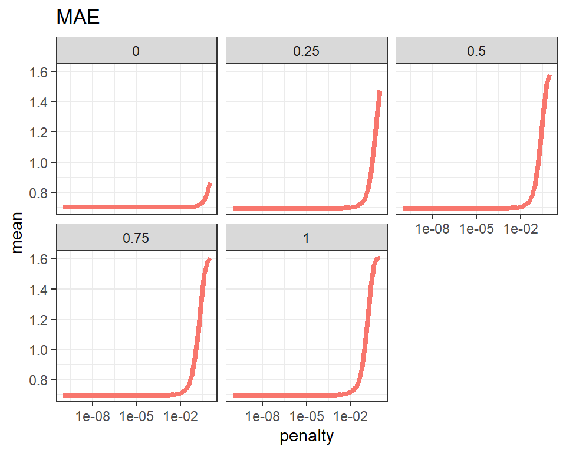

```r
tune_result %>%
  collect_metrics() %>%
  filter(.metric == "mae") %>%
  ggplot(aes(penalty, mean, color = .metric)) +
  geom_line(size = 1.5) +
  scale_x_log10() +
  facet_wrap(vars(as_factor(mixture))) +
  theme(legend.position = "none") +
  labs(title = "MAE")
```

```r
tune_result %>% show_best(metric = "mae") %>% kable()
```

| penalty | mixture | .metric | .estimator | mean | n | std_err | .config |
| --- | --- | --- | --- | --- | --- | --- | --- |
| 0.0005429 | 0.25 | mae | standard | 0.6942144 | 10 | 0.0010765 | Preprocessor1_Model084 |
| 0.0000000 | 0.25 | mae | standard | 0.6942169 | 10 | 0.0010742 | Preprocessor1_Model051 |
| 0.0000000 | 0.25 | mae | standard | 0.6942169 | 10 | 0.0010742 | Preprocessor1_Model052 |
| 0.0000000 | 0.25 | mae | standard | 0.6942169 | 10 | 0.0010742 | Preprocessor1_Model053 |
| 0.0000000 | 0.25 | mae | standard | 0.6942169 | 10 | 0.0010742 | Preprocessor1_Model054 |

```r
tune_best <- tune_result %>% select_best(metric = "mae")
tune_best$penalty
```

```
## [1] 0.0005428675
```

```r
tune_best$mixture
```

```
## [1] 0.25
```

# 6 Elastic Net regeression 모델 설정 및 학습

`mixture`와 `penalty` 모수를 튜닝 된 최적 모수로 학습시킨다.

```r
ridge_model <-
    linear_reg(penalty = tune_best$penalty, # tuned penalty
               mixture = tune_best$mixture) %>% # lasso: 1, ridge: 0
    set_engine("glmnet")

ridge_fit <-
    ridge_model %>%
    fit(weekly_sales ~ ., data = train2)

options(max.print = 10)
ridge_fit %>%
    tidy() %>%
    filter(estimate > 0.001) %>%
    kable()
```

| term | estimate | penalty |
| --- | --- | --- |
| (Intercept) | 5.8715495 | 0.0005429 |
| is_holidayTRUE | 0.0398911 | 0.0005429 |
| size | 0.5149795 | 0.0005429 |
| mark_down1 | 0.0061443 | 0.0005429 |
| mark_down2 | 0.0116413 | 0.0005429 |
| mark_down3 | 0.0145623 | 0.0005429 |
| date_USCPulaskisBirthday | 0.0022473 | 0.0005429 |
| date_USDecorationMemorialDay | 0.0039112 | 0.0005429 |
| date_USGoodFriday | 0.0265284 | 0.0005429 |
| date_USIndependenceDay | 0.0107938 | 0.0005429 |
| date_USLaborDay | 0.0017677 | 0.0005429 |
| date_USLincolnsBirthday | 0.0094548 | 0.0005429 |
| date_USNewYearsDay | 0.0051554 | 0.0005429 |
| date_USPresidentsDay | 0.0036367 | 0.0005429 |
| date_USThanksgivingDay | 0.0346890 | 0.0005429 |
| date_USVeteransDay | 0.0017219 | 0.0005429 |
| temperature_poly_1 | 0.0329994 | 0.0005429 |
| temperature_poly_5 | 0.0123623 | 0.0005429 |
| temperature_poly_9 | 0.0036466 | 0.0005429 |
| temperature_poly_10 | 0.0016717 | 0.0005429 |
| fuel_price_poly_3 | 0.0029661 | 0.0005429 |
| fuel_price_poly_6 | 0.0028408 | 0.0005429 |
| fuel_price_poly_8 | 0.0057689 | 0.0005429 |
| fuel_price_poly_9 | 0.0038434 | 0.0005429 |
| cpi_poly_1 | 0.0568437 | 0.0005429 |
| cpi_poly_2 | 0.0703399 | 0.0005429 |
| cpi_poly_3 | 0.0352990 | 0.0005429 |
| cpi_poly_5 | 0.0124431 | 0.0005429 |
| cpi_poly_6 | 0.0073348 | 0.0005429 |
| cpi_poly_7 | 0.0043030 | 0.0005429 |
| unemployment_poly_2 | 0.0130180 | 0.0005429 |
| unemployment_poly_5 | 0.0017117 | 0.0005429 |
| unemployment_poly_7 | 0.0050343 | 0.0005429 |
| unemployment_poly_9 | 0.0065974 | 0.0005429 |
| store_X4 | 0.0299651 | 0.0005429 |
| store_X10 | 0.1229360 | 0.0005429 |
| store_X12 | 0.0175173 | 0.0005429 |
| store_X13 | 0.0097781 | 0.0005429 |
| store_X14 | 0.0578484 | 0.0005429 |
| store_X17 | 0.0184971 | 0.0005429 |
| store_X18 | 0.0187446 | 0.0005429 |
| store_X20 | 0.0186436 | 0.0005429 |
| store_X22 | 0.0076399 | 0.0005429 |
| store_X23 | 0.0708765 | 0.0005429 |
| store_X42 | 0.0032450 | 0.0005429 |
| dept_X2 | 0.1758783 | 0.0005429 |
| dept_X4 | 0.0846669 | 0.0005429 |
| dept_X8 | 0.1027874 | 0.0005429 |
| dept_X13 | 0.1131319 | 0.0005429 |
| dept_X23 | 0.0038690 | 0.0005429 |
| dept_X38 | 0.2645851 | 0.0005429 |
| dept_X40 | 0.1900510 | 0.0005429 |
| dept_X46 | 0.0234710 | 0.0005429 |
| dept_X65 | 0.0299081 | 0.0005429 |
| dept_X72 | 0.1217419 | 0.0005429 |
| dept_X79 | 0.0433938 | 0.0005429 |
| dept_X90 | 0.1548459 | 0.0005429 |
| dept_X91 | 0.0818462 | 0.0005429 |
| dept_X92 | 0.2801482 | 0.0005429 |
| dept_X93 | 0.0039396 | 0.0005429 |
| dept_X94 | 0.0043538 | 0.0005429 |
| dept_X95 | 0.2816924 | 0.0005429 |
| date_month_Feb | 0.0591571 | 0.0005429 |
| date_month_Mar | 0.0415744 | 0.0005429 |
| date_month_Apr | 0.0267476 | 0.0005429 |
| date_month_May | 0.0308562 | 0.0005429 |
| date_month_Jun | 0.0389399 | 0.0005429 |
| date_month_Jul | 0.0260244 | 0.0005429 |
| date_month_Aug | 0.0284212 | 0.0005429 |
| date_month_Sep | 0.0051067 | 0.0005429 |
| date_month_Oct | 0.0225548 | 0.0005429 |
| date_month_Nov | 0.0297961 | 0.0005429 |
| date_month_Dec | 0.1332027 | 0.0005429 |

# 7 Prediction and submit (예측 및 평가)

```r
result <- predict(ridge_fit, test2)
result %>% head()
```

```
## # A tibble: 6 x 1
##   .pred
##   <dbl>
## 1  7.52
## 2  7.53
## 3  7.52
## 4  7.96
## 5  7.51
## 6  7.91
```

```r
result %<>%
  mutate(.pred = sign(.pred) * (abs(.pred)^5))
  # mutate(.pred = sign(.pred) * (abs(exp(.pred)) - 2))
```

```r
submission <- read_csv(file.path(file_path, "sampleSubmission.csv.zip"))
submission$Weekly_Sales <- result$.pred
write.csv(submission, row.names = FALSE,
          "elastic_regression_tuned_imputmk.csv")
submission %>% head()
```

```
## # A tibble: 6 x 2
##   Id             Weekly_Sales
##   <chr>                 <dbl>
## 1 1_1_2012-11-02       24014.
## 2 1_1_2012-11-09       24277.
## 3 1_1_2012-11-16       23979.
## 4 1_1_2012-11-23       31902.
## 5 1_1_2012-11-30       23837.
## 6 1_1_2012-12-07       31030.
```